# Fronteira Eficiente de Markowitz

Victor Santana

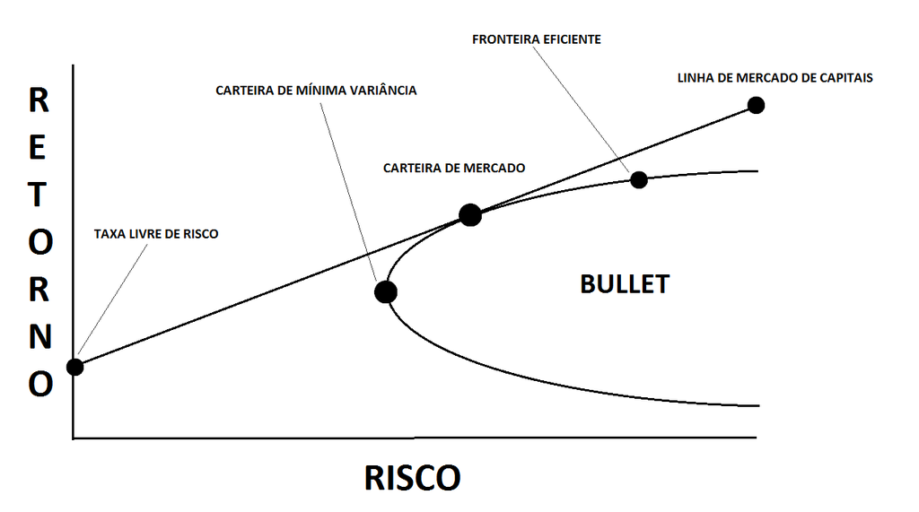

# 1 Introdução

Esse trabalho consiste na formulação de um código em Python capaz de simular diversas carteiras de investimentos, e dentre essas, procura pelas carteiras mais eficientes. O critério utilizado para avaliar a eficiência das carteiras será o da Fronteira Eficiente, um conceito apresentado por Harry Markowitz (criador da teoria moderna do portfólio e vencedor do prêmio Nobel de Economia em 1990). Os dados históricos das ações foram importados da biblioteca yfinance do Python.

# 2 Gerando Carteiras

Para gerar as carteiras aleatórias serão importados os dados a respeito do fechamento ajustado de cada ação escolhida no período de 2000 até 2024. As ações selecionadas para compor as carteiras serão PETROBRAS (PETR3.SA), VALE (VALE3.SA), LIGHT (LIGT3.SA), BRADESCO (BBDC3.SA) e BANCO DO BRASIL (BBAS3.SA). Contudo, é importante notar que poderiam ser escolhidas quaisquer ações da bolsa e o código continuaria funcionando. Também será criada uma função para gerar os pesos aleatórios para cada ação dentro das 100000 (esse número também é arbitrário) carteiras aleatórias.

```python
# Importando as Bibliotecas.
import pandas as pd
import numpy as np
import matplotlib.pyplot as plt
import seaborn as sns
import yfinance as yf

# Definir as ações que vão ser trabalhadas.
acoes = [
         'PETR3.SA',
         'VALE3.SA',
         'LIGT3.SA',
         'BBDC3.SA',
         'BBAS3.SA'
]

# Criar o DataFrame da carteira.
portfolio = pd.DataFrame()

# Pegando os dados do yfinance a respeito
# do fechamento ajustado de cada ação e adicionando ao DataFrame.
for acao in acoes:
  portfolio[acao] = yf.download(acao, period='max')['Adj Close']
```

```
##
[*********************100%%**********************]  1 of 1 completed
##
[*********************100%%**********************]  1 of 1 completed
##
[*********************100%%**********************]  1 of 1 completed
##
[*********************100%%**********************]  1 of 1 completed
##
[*********************100%%**********************]  1 of 1 completed
```

```python
portfolio
```

```
##              PETR3.SA   VALE3.SA   LIGT3.SA   BBDC3.SA   BBAS3.SA
## Date
## 2000-01-03   1.467328   1.600482  47.518936   1.078576   1.074564
## 2000-01-04   1.384977   1.562375  49.243214   1.000134   1.023456
## 2000-01-05   1.403694   1.562375  52.945332   1.034126   1.033940
## 2000-01-06   1.392465   1.562375  57.408142   1.049814   1.048355
## 2000-01-07   1.403694   1.619534  55.683876   1.068116   1.024767
## ...               ...        ...        ...        ...        ...
## 2024-02-01  42.959999  67.449997   5.900000  13.722750  57.740002
## 2024-02-02  42.330002  66.080002   5.780000  13.640000  57.720001
## 2024-02-05  42.330002  65.510002   5.640000  13.910000  58.340000
## 2024-02-06  42.970001  66.669998   5.600000  14.520000  59.599998
## 2024-02-07  43.130001  66.639999   5.640000  12.800000  59.470001
##
## [5978 rows x 5 columns]
```

```python
# Calculando o retorno das ações.
retorno = portfolio.pct_change()

# Calculando medidas estatísticas dos retornos de cada ação.

# Retorno médio anual.
retorno_anual = retorno.mean()*252

# Covariância.
cov = retorno.cov()*252

# Criando portfolios aleatórios.
qnt_portfolios = 100000
qnt_acoes = len(acoes)

# Função para gerar pesos aleatórios.
def weight(qnt_acoes):
    pesos = []
    while sum(pesos) != 1.0:
            pesos = []
            aleatorio = np.random.random(qnt_acoes)
            for i in range(qnt_acoes):
                pesos.append(round(aleatorio[i]/sum(aleatorio), 2))
    return pesos
```

## 2.1 Calculando o Retorno Esperado, Volatilidade e o Índice Sharpe

```python
# Criando os portfolios baseados nos pesos aleatórios gerados.
pesos = []
retorno_esperado = []
volatilidade = []
sharpe = []

# Iterando cada peso aleatório para gerar o retorno esperado, volatilidade e o sharpe.
for i in range(qnt_portfolios):
    pesos.append(np.array(weight(qnt_acoes=qnt_acoes)))
    retorno_esperado.append(np.dot(pesos[i], retorno_anual))
    volatilidade.append(np.sqrt(np.dot(pesos[i].T, np.dot(cov, pesos[i]))))
    sharpe.append(retorno_esperado[i]/volatilidade[i])


# Criando o DataFrame com os portfolios.
dic_portfolio = {
    'Retorno': retorno_esperado,
    'Volatilidade': volatilidade,
    'Índice Sharpe': sharpe
}
Portfolio = pd.DataFrame(dic_portfolio)
Portfolio
```

```
##         Retorno  Volatilidade  Índice Sharpe
## 0      0.205782      0.307073       0.670140
## 1      0.191231      0.304193       0.628651
## 2      0.168655      0.332336       0.507485
## 3      0.235930      0.333139       0.708204
## 4      0.166804      0.302377       0.551642
## ...         ...           ...            ...
## 99995  0.152756      0.323389       0.472360
## 99996  0.184217      0.326188       0.564757
## 99997  0.215731      0.318506       0.677320
## 99998  0.175720      0.319384       0.550184
## 99999  0.184948      0.312358       0.592104
##
## [100000 rows x 3 columns]
```

# 3 Plotando os gráficos

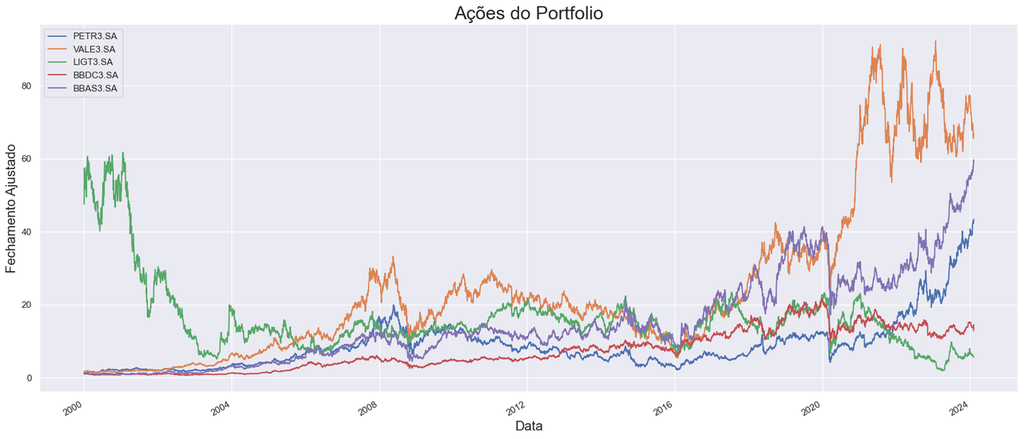

```python
# Plotando o gráfico da carteira ao londo do período estipulado.
sns.set_theme()
portfolio.plot(figsize=(21,9))
plt.xlabel('Data', fontsize=16)
plt.ylabel('Fechamento Ajustado', fontsize=16)
plt.title('Ações do Portfolio', fontsize=22)
```

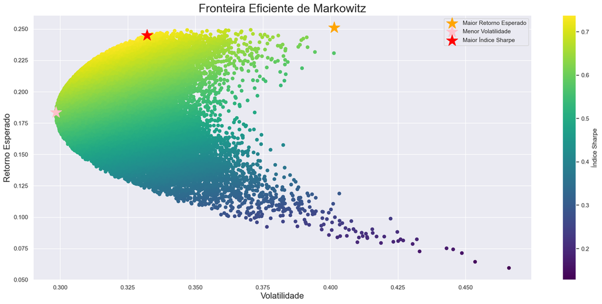

```python
# Carteiras de destaque.

# Maior Retorno esperado.
maior_retorno = Portfolio[
    max(Portfolio['Retorno']) == Portfolio['Retorno']
]

# Menor Volatilidade (risco).
menor_volatilidade = Portfolio[
    min(Portfolio['Volatilidade']) == Portfolio['Volatilidade']
]

# Maior Sharpe
maior_sharpe = Portfolio[
    max(Portfolio['Índice Sharpe']) == Portfolio['Índice Sharpe']
]

# Plotando os portfolios no gráfico de dispersão.
plt.figure(figsize=(21,9))
plt.scatter(
    Portfolio['Volatilidade'],
    Portfolio['Retorno'],
    c=Portfolio['Índice Sharpe'],
    cmap='viridis',
)

plt.xlabel('Volatilidade', fontsize=16)
plt.ylabel('Retorno Esperado', fontsize=16)
plt.title('Fronteira Eficiente de Markowitz', fontsize=22)
plt.colorbar(label='Índice Sharpe')

# Ponto maior retorno.
plt.scatter(
    maior_retorno['Volatilidade'],
    maior_retorno['Retorno'],
    c='orange',
    label='Maior Retorno Esperado',
     marker='*',
     s=500
)

# Ponto menor volatilidade.
plt.scatter(
    menor_volatilidade['Volatilidade'],
    menor_volatilidade['Retorno'],
    c='pink',
    label='Menor Volatilidade',
    marker="*",
    s=500
)

# Maior índice sharpe.
plt.scatter(
    maior_sharpe['Volatilidade'],
    maior_sharpe['Retorno'],
    c='red',
    label='Maior Índice Sharpe',
    marker='*',
    s=500
)
plt.legend()
plt.show()
```

# 4 Conclusão

Descobrindo quais são as carteiras com o maior retorno esperado, menor volatilidade e maior índice sharpe.

```python
# Função para retornar o peso de cada ação dado uma linha do DataFrame.
def get_weight(valor):
    lista_pesos = list(pesos[valor.iloc()[0].name])
    df = pd.DataFrame(columns=acoes, data=[lista_pesos])
    return print(df.to_string(index=False))

# Pontos Críticos.
print('Carteira com maior Retorno Esperado:')
get_weight(maior_retorno)


print('Carteira com menor Volatilidade:')
get_weight(menor_volatilidade)


print('Carteira com maior índice Sharpe:')
get_weight(maior_sharpe)
```

```
## Carteira com maior Retorno Esperado:
```

```
##  PETR3.SA  VALE3.SA  LIGT3.SA  BBDC3.SA  BBAS3.SA
##      0.03      0.22      0.01      0.02      0.72
```

```
## Carteira com menor Volatilidade:
```

```
##  PETR3.SA  VALE3.SA  LIGT3.SA  BBDC3.SA  BBAS3.SA
##      0.07      0.32      0.16      0.37      0.08
```

```
## Carteira com maior índice Sharpe:
```

```
##  PETR3.SA  VALE3.SA  LIGT3.SA  BBDC3.SA  BBAS3.SA
##      0.15      0.41       0.0      0.05      0.39
```